# Saqrlab Reference — TNA simulation

The TNA-simulation family generates synthetic Temporal Network Analysis data with known ground-truth parameters. The `simulate_tna_*` functions build fitted `tna`/`group_tna` model objects (ready for the `tna` package), `simulate_*_matrix`/`simulate_htna` return transition matrices with node groupings for hierarchical/multilevel plots, and `generate_probabilities` produces the underlying Markov probabilities. The `generate_*` names are silent backward-compatibility aliases of their `simulate_*` counterparts and produce identical output. All examples below are seeded and kept small for fast rendering.

## `simulate_tna_network()`

Generate a single fitted TNA network model with learning-state names — the simplest way to obtain a ready-to-use `tna` object (`$weights`, `$inits`, `$labels`, `$data`).

**Signature**

```r
args(simulate_tna_network)
```

```
#> function (n_states = 9, n_sequences = NULL, seq_length = 25,
#>     categories = c("metacognitive", "cognitive"), seed = NULL)
#> NULL
```

**Example**

```r
model <- simulate_tna_network(n_states = 4, seed = 1)
class(model)
```

```
#> [1] "tna"
```

```r
names(model)
```

```
#> [1] "weights" "inits"   "labels"  "data"
```

```r
head(round(model$weights, 3))     # transition weights; rows sum to 1
```

```
#>               Analyze Differentiate Elaborate Track
#> Analyze         0.345         0.270     0.020 0.365
#> Differentiate   0.129         0.268     0.255 0.348
#> Elaborate       0.165         0.292     0.098 0.446
#> Track           0.195         0.304     0.114 0.387
```

```r
round(rowSums(model$weights), 3)
```

```
#>       Analyze Differentiate     Elaborate         Track
#>             1             1             1             1
```

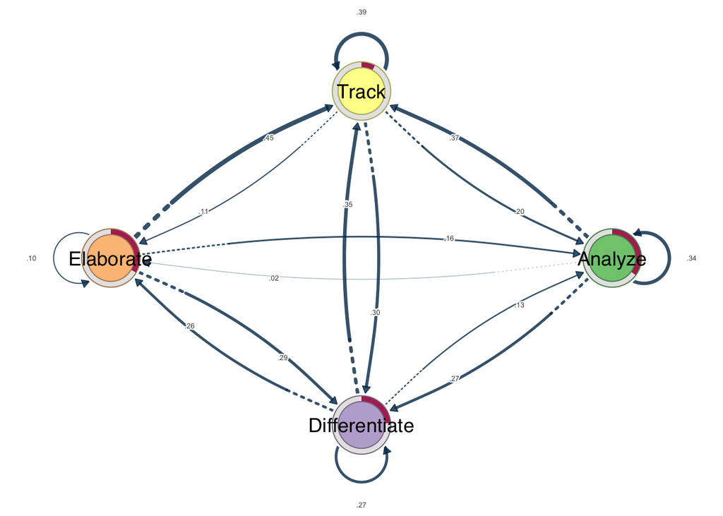

```r
# tna ships a plot method; guard it in case the suggested deps are absent
invisible(try(plot(model), silent = TRUE))
```

## `simulate_tna_networks()`

Simulate multiple independent TNA network objects for simulation studies, returning a named list of fitted `tna` models (no underlying data/probabilities). Alias: `generate_tna_networks()`.

**Signature**

```r
args(simulate_tna_networks)
```

```
#> function (n_networks = 1, n_states = 8, n_sequences = 100, seq_length = 30,
#>     model_type = "tna", use_learning_states = TRUE, categories = NULL,
#>     seed = NULL, verbose = TRUE, num_sequences = NULL, max_seq_length = NULL,
#>     learning_categories = NULL, ...)
#> NULL
```

**Example**

```r
nets <- simulate_tna_networks(
  n_networks = 2, n_states = 4, n_sequences = 30, seq_length = 10,
  seed = 1, verbose = FALSE
)
length(nets)
```

```
#> [1] 2
```

```r
names(nets)
```

```
#> [1] "network_1" "network_2"
```

```r
class(nets[[1]])
```

```
#> [1] "tna"
```

```r
head(round(nets[[1]]$weights, 3))
```

```
#>         Adapt Monitor  Plan Reflect
#> Adapt   0.260   0.589 0.041   0.110
#> Monitor 0.526   0.018 0.053   0.404
#> Plan    0.476   0.143 0.143   0.238
#> Reflect 0.109   0.084 0.059   0.748
```